# Practical Lab 1: Univariate Linear Regression on the California Housing Prices Dataset

- Name: Madalina Tilvan
- ID: 9058215

## Framing the Problem

My goal is to conduct a Exploratory Data Analysis (EDA) between the dependent variable (`median_house_value`) and each of the following independent variables (`median_income`, `population` and `households`). Based on the findings, I will select the model that provides the best fit.

```python
import pandas as pd
import seaborn as sns
import matplotlib.pyplot as plt

from sklearn.linear_model import LinearRegression
from sklearn.model_selection import train_test_split
from sklearn.metrics import mean_squared_error, mean_absolute_error
```

## Getting the Data

```python
## using kagglehub to get the dataset and zipfile to unzip it
import kagglehub
import zipfile

path = kagglehub.dataset_download("camnugent/california-housing-prices", path='housing.csv')

## extracts the csv file to a folder inside the environment called dataset
with zipfile.ZipFile(path, "r") as zip_ref:
    zip_ref.extractall("dataset")

## read csv file using pandas
housing_df = pd.read_csv("dataset/housing.csv")
```

## Exploratory Data Analysis (EDA)

```python
## explore statistics
housing_df.describe()
```

|  | longitude | latitude | housing_median_age | total_rooms | total_bedrooms | population | households | median_income | median_house_value |
| --- | --- | --- | --- | --- | --- | --- | --- | --- | --- |
| count | 20640.000000 | 20640.000000 | 20640.000000 | 20640.000000 | 20433.000000 | 20640.000000 | 20640.000000 | 20640.000000 | 20640.000000 |
| mean | -119.569704 | 35.631861 | 28.639486 | 2635.763081 | 537.870553 | 1425.476744 | 499.539680 | 3.870671 | 206855.816909 |
| std | 2.003532 | 2.135952 | 12.585558 | 2181.615252 | 421.385070 | 1132.462122 | 382.329753 | 1.899822 | 115395.615874 |
| min | -124.350000 | 32.540000 | 1.000000 | 2.000000 | 1.000000 | 3.000000 | 1.000000 | 0.499900 | 14999.000000 |
| 25% | -121.800000 | 33.930000 | 18.000000 | 1447.750000 | 296.000000 | 787.000000 | 280.000000 | 2.563400 | 119600.000000 |
| 50% | -118.490000 | 34.260000 | 29.000000 | 2127.000000 | 435.000000 | 1166.000000 | 409.000000 | 3.534800 | 179700.000000 |
| 75% | -118.010000 | 37.710000 | 37.000000 | 3148.000000 | 647.000000 | 1725.000000 | 605.000000 | 4.743250 | 264725.000000 |
| max | -114.310000 | 41.950000 | 52.000000 | 39320.000000 | 6445.000000 | 35682.000000 | 6082.000000 | 15.000100 | 500001.000000 |

### Variables used for the analysis:

##### Median House Value (`median_house_value`)

- Meaning: Median cost of the households within a block.
- Range: Varies between minimum of `$14,999` and maximum of `$500,001`.
- Characteristics:
  - Measured in US dollars.
  - Continuous numerical variable.
  - The maximum value may indicate the presence of outliers in the data.
  - Dependent variable used in the analysis to examine the relationship with the other independent variables.

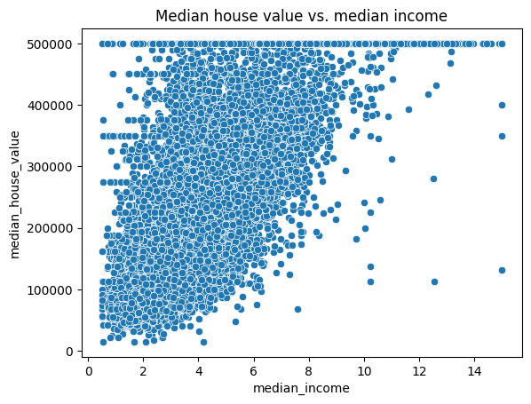

```python
## plot median house value vs. median income
income_scatterplot = sns.scatterplot(x="median_income", y="median_house_value", data=housing_df)
income_scatterplot.set_title("Median house value vs. median income")
```

As the median income increases, the median value of the house tends to rise as well. However, the scattered data points suggest variability, indicating a lot of noise in the data. Additionally, there are outliers on the top of the distribution, which suggests that the dataset needs to be processed before conducting a linear regression.

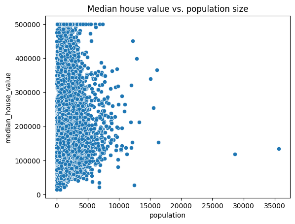

```python
## plot median house value vs. population
population_scatterplot = sns.scatterplot(x="population", y="median_house_value", data=housing_df)
population_scatterplot.set_title("Median house value vs. population size")
```

This plot indicates that changes in the **median house value** do not affect the **population** size. Since the data points are clustered at the left side of the plot, it indicates a weak to non-existent relationship between population size and median house value, with considerable noise in the data.

Because there doesn't seem to be any observable trend, we may need to look into other factors that would be more meaningful for conducting a linear regression.

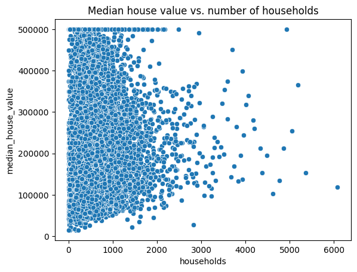

```python
## plot median house value vs. number of households
households_scatterplot = sns.scatterplot(x="households", y="median_house_value", data=housing_df)
households_scatterplot.set_title("Median house value vs. number of households")
```

As previously stated, there doesn't seem to be any relationship between **median house value** and the **number of households** either. The data is mostly clustered at the left side of the plot, and there seems to be a lot of variability which indicates that our data contains a lot of noise.

Because there doesn't seem to be any observable trend, we may need to look into other factors that would be more meaningful for conducting a linear regression.

## Fitting models - Linear regression

**Data preprocessing:** We observed earlier in the visualizations that the median house value has outliers that constrict us from conducting a linear regression. Therefore, we need to remove these extreme values before continuing.

```python
housing_df_preprocessed = housing_df[housing_df.median_house_value != 500001]
```

The dependent variable (y) would be the same for all three regression models.

```python
y = housing_df_preprocessed[["median_house_value"]]
```

#### Model 1: median house value vs. median income

1. Train and test split

```python
X_income = housing_df_preprocessed[["median_income"]]
X_train_income, X_test_income, y_train_income, y_test_income = train_test_split(X_income, y, test_size=0.2, random_state=0)
```

2. Train the model

   We'll use the `sklearn.linear_model.LinearRegression` to fit the model on the training data.

```python
model1 = LinearRegression()
model1.fit(X_train_income, y_train_income)
```

```
LinearRegression()
```

3. Evaluate the model

   We'll make predictions using the training set, then calculate the Mean Squared Error (MSE) and the Mean Absolute Error (MAE).

```python
y_pred_income = model1.predict(X_train_income)

## Calculate errors
train_mse_income = mean_squared_error(y_train_income, y_pred_income)
train_mae_income = mean_absolute_error(y_train_income, y_pred_income)
```

Now, we'll do the same for the other two models.

#### Model 2: median house value vs. population

```python
# 1. Train and test split
X_population = housing_df_preprocessed[["population"]]
X_train_population, X_test_population, y_train_population, y_test_population = train_test_split(X_population, y, test_size=0.2, random_state=0)

# 2. Train the model
model2 = LinearRegression()
model2.fit(X_train_population, y_train_population)

# 3. Evaluate the model
# Make predictions
y_pred_population = model2.predict(X_train_population)

## Calculate errors
train_mse_population = mean_squared_error(y_train_population, y_pred_population)
train_mae_population = mean_absolute_error(y_train_population, y_pred_population)
```

#### Model 3: median house value vs. number of households

```python
# 1. Train and test split
X_households = housing_df_preprocessed[["households"]]
X_train_households, X_test_households, y_train_households, y_test_households = train_test_split(X_households, y, test_size=0.2, random_state=0)

# 2. Train the model
model3 = LinearRegression()
model3.fit(X_train_households, y_train_households)

# 3. Evaluate the model
# Make predictions
y_pred_households = model3.predict(X_train_households)

## Calculate errors
train_mse_households = mean_squared_error(y_train_households, y_pred_households)
train_mae_households = mean_absolute_error(y_train_households, y_pred_households)
```

## Regression model comparison: Intercept, slope, MAE, and MSE

```python
## Model 1 = median house value vs median income
## Model 2 = median house value vs population
## Model 3 = median house value vs number of households
regression_models = {
    "Model": ["Model 1", "Model 2", "Model 3"],
    "y-intercept": [model1.intercept_[0], model2.intercept_[0], model3.intercept_[0]],
    "slope": [model1.coef_[0][0], model2.coef_[0][0], model3.coef_[0][0]],
    "MAE": [train_mae_income, train_mae_population, train_mae_households],
    "MSE": [train_mse_income, train_mse_population, train_mse_households]
}

df_models = pd.DataFrame(regression_models)
print(df_models)
```

```
     Model    y-intercept         slope           MAE           MSE
0  Model 1   44515.608326  40268.328624  56690.540547  5.552143e+09
1  Model 2  190430.699607      1.355571  78218.576363  9.531889e+09
2  Model 3  179991.287289     24.755049  77694.176678  9.445093e+09
```

### Regression Model 1: median house value vs. median income

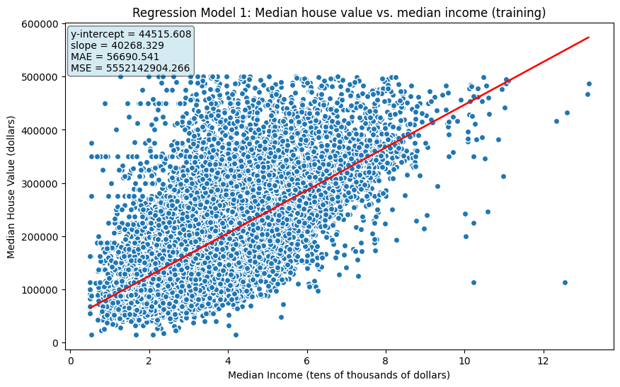

```python
fig, ax = plt.subplots(figsize=(10,6))

text = '\n'.join((
        r"y-intercept = %.3f" % model1.intercept_[0],
        r"slope = %.3f" % model1.coef_[0][0],
        r"MAE = %.3f" %  train_mae_income,
        r"MSE = %.3f" % train_mse_income))
props = dict(boxstyle='round', facecolor='lightblue', alpha=0.5)

ax.scatter(X_train_income, y_train_income, edgecolors='white')
ax.plot(X_train_income, y_pred_income, color='red')
ax.text(0.01, 0.98, text, transform=ax.transAxes, verticalalignment='top', bbox=props)

ax.set_title("Regression Model 1: Median house value vs. median income (training)")
ax.set_xlabel("Median Income (tens of thousands of dollars)")
ax.set_ylabel("Median House Value (dollars)")

plt.show()
```

The intercept further tells us that the base median house prices fall around `$44,500` thousand dollars even when the median income is zero.

The Mean Absolute Error (MAE) indicates that the predictions deviate from the actual house values by `$56,700`, suggesting that **our model is not very accurate**.

Since Mean Squared Error (MSE) is larger than MAE, we can conclude that outliers are affecting our model.

### Regression Model 2: median house value vs. population

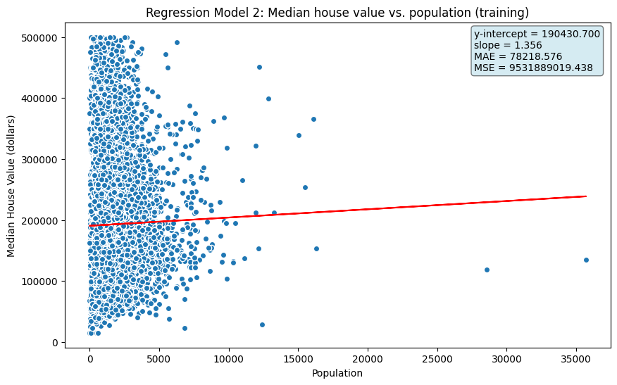

```python
fig, ax = plt.subplots(figsize=(10,6))

text = '\n'.join((
        r"y-intercept = %.3f" % model2.intercept_[0],
        r"slope = %.3f" % model2.coef_[0][0],
        r"MAE = %.3f" %  train_mae_population,
        r"MSE = %.3f" % train_mse_population))
props = dict(boxstyle='round', facecolor='lightblue', alpha=0.5)

ax.scatter(X_train_population, y_train_population, edgecolors='white')
ax.plot(X_train_population, y_pred_population, color='red')
ax.text(0.75, 0.98, text, transform=ax.transAxes, verticalalignment='top', bbox=props)

ax.set_title("Regression Model 2: Median house value vs. population (training)")
ax.set_xlabel("Population")
ax.set_ylabel("Median House Value (dollars)")

plt.show()
```

There seems to be **a weak correlation** between the median house value and the population sample, as indicated by the slope of 1.35.

The intercept further tells us that the base median house prices fall around `$190,000` when the population is zero.

The Mean Absolute Error (MAE) indicates that the predictions deviate from the actual values by `$78,200`, suggesting that this model is **less accurate than Model 1**.

Since Mean Squared Error (MSE) is larger than MAE, outliers are affecting our model significantly.

### Regression Model 3: median house value vs. number of households

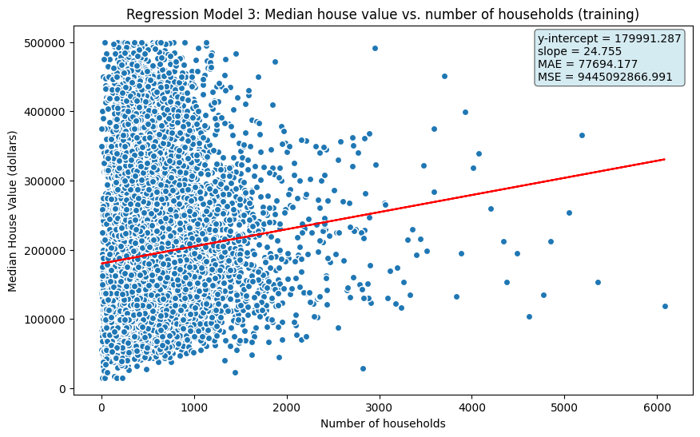

```python
fig, ax = plt.subplots(figsize=(10,6))

# text box - text
text = '\n'.join((
        r"y-intercept = %.3f" % model3.intercept_[0],
        r"slope = %.3f" % model3.coef_[0][0],
        r"MAE = %.3f" %  train_mae_households,
        r"MSE = %.3f" % train_mse_households))
# text box - box properties
props = dict(boxstyle='round', facecolor='lightblue', alpha=0.5)

ax.scatter(X_train_households, y_train_households, edgecolors='white')
ax.plot(X_train_households, y_pred_households, color='red')
ax.text(0.75, 0.98, text, transform=ax.transAxes, verticalalignment='top', bbox=props)

ax.set_title("Regression Model 3: Median house value vs. number of households (training)")
ax.set_xlabel("Number of households")
ax.set_ylabel("Median House Value (dollars)")

plt.show()
```

The intercept value tells us that the base median house prices fall around `$180,000` when the number of households is zero.

Since Mean Squared Error (MSE) is larger than MAE, we can conclude that outliers are affecting our model.

## Summary

Based on the Exploratory Component Analysis conducted, **Model 1** is the best fit because it has the lowest Mean Absolute Error (MAE) as well as the lowest Mean Squared Error (MSE). This tells us that the predictions of Model 1 are closer to the actual values compared to the other models.